# Stat 115 Lab 10

R Tips and Tricks

Andy Shi

April 3-5, 2018

## Outline of Lab

1. `data.table`: Easier way to manipulate data
2. Joins
3. Tidy data
4. Adding text to plots

## Install and Load Packages

```r
install.packages("data.table")
install.packages("ggplot2")
install.packages("ggrepel")
install.packages("tidyr")
# etc.
```

```r
library(data.table)
library(ggplot2)
library(ggrepel)
library(tidyr)
```

## data.table Introduction

- Data science (and bioinformatics!) is 80% data cleaning, 20% analysis.
- Make the data cleaning part as painless as possible.
- An enhanced version of R’s built-in `data.frame`.
- General form of syntax: `DT[i, j, by]`
- Material adapted from `data.table` vignette: https://cran.r-project.org/web/packages/data.table/vignettes/datatable-intro.html

## Data

- NYC flights from 2014

```r
DT = data.table(ID = c("b","b","b","a","a","c"), a = 1:6, b = 7:12, c = 13:18)
DT
```

```
##    ID a  b  c
## 1:  b 1  7 13
## 2:  b 2  8 14
## 3:  b 3  9 15
## 4:  a 4 10 16
## 5:  a 5 11 17
## 6:  c 6 12 18
```

```r
flights <- fread("https://raw.githubusercontent.com/wiki/arunsrinivasan/flights/NYCflights14/flights14.csv")
head(flights)
```

```
##    year month day dep_time dep_delay arr_time arr_delay cancelled carrier
## 1: 2014     1   1      914        14     1238        13         0      AA
## 2: 2014     1   1     1157        -3     1523        13         0      AA
## 3: 2014     1   1     1902         2     2224         9         0      AA
## 4: 2014     1   1      722        -8     1014       -26         0      AA
## 5: 2014     1   1     1347         2     1706         1         0      AA
## 6: 2014     1   1     1824         4     2145         0         0      AA
##    tailnum flight origin dest air_time distance hour min
## 1:  N338AA      1    JFK  LAX      359     2475    9  14
## 2:  N335AA      3    JFK  LAX      363     2475   11  57
## 3:  N327AA     21    JFK  LAX      351     2475   19   2
## 4:  N3EHAA     29    LGA  PBI      157     1035    7  22
## 5:  N319AA    117    JFK  LAX      350     2475   13  47
## 6:  N3DEAA    119    EWR  LAX      339     2454   18  24
```

## Subsetting

- Focus on i and j for `DT[i, j, by]`
- `i` controls the rows
- `j` controls the columns

```r
ans <- flights[origin == "JFK" & month == 6,]
head(ans)
```

```
##    year month day dep_time dep_delay arr_time arr_delay cancelled carrier
## 1: 2014     6   1      851        -9     1205        -5         0      AA
## 2: 2014     6   1     1220       -10     1522       -13         0      AA
## 3: 2014     6   1      718        18     1014        -1         0      AA
## 4: 2014     6   1     1024        -6     1314       -16         0      AA
## 5: 2014     6   1     1841        -4     2125       -45         0      AA
## 6: 2014     6   1     1454        -6     1757       -23         0      AA
##    tailnum flight origin dest air_time distance hour min
## 1:  N787AA      1    JFK  LAX      324     2475    8  51
## 2:  N795AA      3    JFK  LAX      329     2475   12  20
## 3:  N784AA      9    JFK  LAX      326     2475    7  18
## 4:  N791AA     19    JFK  LAX      320     2475   10  24
## 5:  N790AA     21    JFK  LAX      326     2475   18  41
## 6:  N785AA    117    JFK  LAX      329     2475   14  54
```

```r
ans <- flights[, arr_delay]
head(ans)
```

```
## [1]  13  13   9 -26   1   0
```

```r
ans <- flights[, .(arr_delay, dep_delay)]
head(ans)
```

```
##    arr_delay dep_delay
## 1:        13        14
## 2:        13        -3
## 3:         9         2
## 4:       -26        -8
## 5:         1         2
## 6:         0         4
```

## Compute in j

- Can use the columns to compute specific values.
- Find flights that had total delay < 0

```r
ans <- flights[, sum((arr_delay + dep_delay) < 0)]
ans
```

```
## [1] 141814
```

- Get mean arrival and departure delays for flights leaving JFK in June.

```r
ans <- flights[origin == "JFK" & month == 6,
               .(m_arr = mean(arr_delay), m_dep = mean(dep_delay))]
ans
```

```
##       m_arr    m_dep
## 1: 5.839349 9.807884
```

- Get number of flights leaving JFK in June.
- `.N` is special variable from `data.table`.

```r
ans <- flights[origin == "JFK" & month == 6, .N]
ans
```

```
## [1] 8422
```

## Selecting using names

- Previously, didn’t have to quote the column names
- You can also use quoted column names using `with = FALSE`.

```r
ans <- flights[, c("arr_delay", "dep_delay"), with = FALSE]
head(ans)
```

```
##    arr_delay dep_delay
## 1:        13        14
## 2:        13        -3
## 3:         9         2
## 4:       -26        -8
## 5:         1         2
## 6:         0         4
```

```r
# returns all columns except arr_delay and dep_delay
ans <- flights[, !c("arr_delay", "dep_delay"), with = FALSE]
head(ans)
```

```
##    year month day dep_time arr_time cancelled carrier tailnum flight
## 1: 2014     1   1      914     1238         0      AA  N338AA      1
## 2: 2014     1   1     1157     1523         0      AA  N335AA      3
## 3: 2014     1   1     1902     2224         0      AA  N327AA     21
## 4: 2014     1   1      722     1014         0      AA  N3EHAA     29
## 5: 2014     1   1     1347     1706         0      AA  N319AA    117
## 6: 2014     1   1     1824     2145         0      AA  N3DEAA    119
##    origin dest air_time distance hour min
## 1:    JFK  LAX      359     2475    9  14
## 2:    JFK  LAX      363     2475   11  57
## 3:    JFK  LAX      351     2475   19   2
## 4:    LGA  PBI      157     1035    7  22
## 5:    JFK  LAX      350     2475   13  47
## 6:    EWR  LAX      339     2454   18  24
```

```r
# or
ans <- flights[, -c("arr_delay", "dep_delay"), with = FALSE]
head(ans)
```

```
##    year month day dep_time arr_time cancelled carrier tailnum flight
## 1: 2014     1   1      914     1238         0      AA  N338AA      1
## 2: 2014     1   1     1157     1523         0      AA  N335AA      3
## 3: 2014     1   1     1902     2224         0      AA  N327AA     21
## 4: 2014     1   1      722     1014         0      AA  N3EHAA     29
## 5: 2014     1   1     1347     1706         0      AA  N319AA    117
## 6: 2014     1   1     1824     2145         0      AA  N3DEAA    119
##    origin dest air_time distance hour min
## 1:    JFK  LAX      359     2475    9  14
## 2:    JFK  LAX      363     2475   11  57
## 3:    JFK  LAX      351     2475   19   2
## 4:    LGA  PBI      157     1035    7  22
## 5:    JFK  LAX      350     2475   13  47
## 6:    EWR  LAX      339     2454   18  24
```

## Aggregation

- `DT[i, j, by]`: by allows us to aggregate.
- Number of flights from each of the 3 NYC airports

```r
ans <- flights[, .(.N), by = .(origin)]
ans
```

```
##    origin     N
## 1:    JFK 81483
## 2:    LGA 84433
## 3:    EWR 87400
```

- Number of flights from each of the 3 NYC airports on American Airlines

```r
ans <- flights[carrier == "AA", .N, by = origin]
ans
```

```
##    origin     N
## 1:    JFK 11923
## 2:    LGA 11730
## 3:    EWR  2649
```

- Number of flights on American Airlines, grouped by origin and destination

```r
ans <- flights[carrier == "AA", .N, by = .(origin, dest)]
head(ans)
```

```
##    origin dest    N
## 1:    JFK  LAX 3387
## 2:    LGA  PBI  245
## 3:    EWR  LAX   62
## 4:    JFK  MIA 1876
## 5:    JFK  SEA  298
## 6:    EWR  MIA  848
```

- Mean arrival and departure delay for American Airlines, by route and month

```r
ans <- flights[carrier == "AA",
        .(m_arr = mean(arr_delay), m_dep = mean(dep_delay)),
        by = .(origin, dest, month)]
head(ans)
```

```
##    origin dest month     m_arr      m_dep
## 1:    JFK  LAX     1  6.590361 14.2289157
## 2:    LGA  PBI     1 -7.758621  0.3103448
## 3:    EWR  LAX     1  1.366667  7.5000000
## 4:    JFK  MIA     1 15.720670 18.7430168
## 5:    JFK  SEA     1 14.357143 30.7500000
## 6:    EWR  MIA     1 11.011236 12.1235955
```

- Number of flights departing and arriving late, departing early and arriving late, etc.

```r
ans <- flights[, .N, .(dep_delay>0, arr_delay>0)]
ans
```

```
##    dep_delay arr_delay      N
## 1:      TRUE      TRUE  72836
## 2:     FALSE      TRUE  34583
## 3:     FALSE     FALSE 119304
## 4:      TRUE     FALSE  26593
```

## .SD and .SDcols

- What if I want to take the mean of several variables?
- By default, `.SD` holds all the columns except the ones in `by`
- Can specify what `.SD` is using `.SDcols`.

```r
flights[carrier == "AA",                       ## Only on trips with carrier "AA"
        lapply(.SD, mean),                     ## compute the mean
        by = .(origin, dest, month),           ## for every 'origin,dest,month'
        .SDcols = c("arr_delay", "dep_delay")] ## for just those specified in .SDcols
```

```
##      origin dest month  arr_delay  dep_delay
##   1:    JFK  LAX     1   6.590361 14.2289157
##   2:    LGA  PBI     1  -7.758621  0.3103448
##   3:    EWR  LAX     1   1.366667  7.5000000
##   4:    JFK  MIA     1  15.720670 18.7430168
##   5:    JFK  SEA     1  14.357143 30.7500000
##  ---
## 196:    LGA  MIA    10  -6.251799 -1.4208633
## 197:    JFK  MIA    10  -1.880184  6.6774194
## 198:    EWR  PHX    10  -3.032258 -4.2903226
## 199:    JFK  MCO    10 -10.048387 -1.6129032
## 200:    JFK  DCA    10  16.483871 15.5161290
```

## Working with References

- In older versions of R (before 3.1), (1) would generate a deep copy of the data. Fixed in later versions, but a deep copy is still created in (2).
- These copies take up time/memory.
- `data.table` avoids this by working with references.

```r
DF = data.frame(ID = c("b","b","b","a","a","c"), a = 1:6, b = 7:12, c = 13:18)
DF
```

```
##   ID a  b  c
## 1  b 1  7 13
## 2  b 2  8 14
## 3  b 3  9 15
## 4  a 4 10 16
## 5  a 5 11 17
## 6  c 6 12 18
```

```r
DF$c <- 18:13                 # (1)
DF$c[DF$ID == "b"] <- 15:13   # (2)
```

## Assignment by Reference Using :=

- Basic Syntax

```r
DT[, c("colA", "colB", ...) := list(valA, valB, ...)]

# when you have only one column to assign to you
# can drop the quotes and list(), for convenience
DT[, colA := valA]

# or

# valA is assigned to colA
# valB is assigned to colB
DT[, `:=`(colA = valA,
          colB = valB,
          ...
)]
```

- Example: calculate speed in mph and total delay

```r
flights[, `:=`(speed = distance / (air_time/60),
               delay = arr_delay + dep_delay)]
head(flights)
```

```
##    year month day dep_time dep_delay arr_time arr_delay cancelled carrier
## 1: 2014     1   1      914        14     1238        13         0      AA
## 2: 2014     1   1     1157        -3     1523        13         0      AA
## 3: 2014     1   1     1902         2     2224         9         0      AA
## 4: 2014     1   1      722        -8     1014       -26         0      AA
## 5: 2014     1   1     1347         2     1706         1         0      AA
## 6: 2014     1   1     1824         4     2145         0         0      AA
##    tailnum flight origin dest air_time distance hour min    speed delay
## 1:  N338AA      1    JFK  LAX      359     2475    9  14 413.6490    27
## 2:  N335AA      3    JFK  LAX      363     2475   11  57 409.0909    10
## 3:  N327AA     21    JFK  LAX      351     2475   19   2 423.0769    11
## 4:  N3EHAA     29    LGA  PBI      157     1035    7  22 395.5414   -34
## 5:  N319AA    117    JFK  LAX      350     2475   13  47 424.2857     3
## 6:  N3DEAA    119    EWR  LAX      339     2454   18  24 434.3363     4
```

## Sub-Assigning

- Notice there are 0 and 24. Let’s get rid of 24 and set it to 0.

```r
flights[, sort(unique(hour))]
```

```
##  [1]  0  1  2  3  4  5  6  7  8  9 10 11 12 13 14 15 16 17 18 19 20 21 22
## [24] 23 24
```

- This will do it by reference. No copies made.

```r
flights[hour == 24, hour := 0]
flights[, sort(unique(hour))]
```

```
##  [1]  0  1  2  3  4  5  6  7  8  9 10 11 12 13 14 15 16 17 18 19 20 21 22
## [24] 23
```

## Delete a Column

```r
flights[, c("delay") := NULL]
# equivalent to flights[, delay := NULL] since we just have 1 variable
```

## Assignment with Grouping Using := and by

- Get max speed for each set of routes
- Can be used to compare a particular flight’s speed to the max speed on that route.

```r
flights[, max_speed := max(speed), by = .(origin, dest)]
head(flights)
```

```
##    year month day dep_time dep_delay arr_time arr_delay cancelled carrier
## 1: 2014     1   1      914        14     1238        13         0      AA
## 2: 2014     1   1     1157        -3     1523        13         0      AA
## 3: 2014     1   1     1902         2     2224         9         0      AA
## 4: 2014     1   1      722        -8     1014       -26         0      AA
## 5: 2014     1   1     1347         2     1706         1         0      AA
## 6: 2014     1   1     1824         4     2145         0         0      AA
##    tailnum flight origin dest air_time distance hour min    speed
## 1:  N338AA      1    JFK  LAX      359     2475    9  14 413.6490
## 2:  N335AA      3    JFK  LAX      363     2475   11  57 409.0909
## 3:  N327AA     21    JFK  LAX      351     2475   19   2 423.0769
## 4:  N3EHAA     29    LGA  PBI      157     1035    7  22 395.5414
## 5:  N319AA    117    JFK  LAX      350     2475   13  47 424.2857
## 6:  N3DEAA    119    EWR  LAX      339     2454   18  24 434.3363
##    max_speed
## 1:  526.5957
## 2:  526.5957
## 3:  526.5957
## 4:  517.5000
## 5:  526.5957
## 6:  518.4507
```

```r
in_cols  = c("dep_delay", "arr_delay")
out_cols = c("max_dep_delay", "max_arr_delay")
flights[, c(out_cols) := lapply(.SD, max), by = month, .SDcols = in_cols]
head(flights)
```

```
##    year month day dep_time dep_delay arr_time arr_delay cancelled carrier
## 1: 2014     1   1      914        14     1238        13         0      AA
## 2: 2014     1   1     1157        -3     1523        13         0      AA
## 3: 2014     1   1     1902         2     2224         9         0      AA
## 4: 2014     1   1      722        -8     1014       -26         0      AA
## 5: 2014     1   1     1347         2     1706         1         0      AA
## 6: 2014     1   1     1824         4     2145         0         0      AA
##    tailnum flight origin dest air_time distance hour min    speed
## 1:  N338AA      1    JFK  LAX      359     2475    9  14 413.6490
## 2:  N335AA      3    JFK  LAX      363     2475   11  57 409.0909
## 3:  N327AA     21    JFK  LAX      351     2475   19   2 423.0769
## 4:  N3EHAA     29    LGA  PBI      157     1035    7  22 395.5414
## 5:  N319AA    117    JFK  LAX      350     2475   13  47 424.2857
## 6:  N3DEAA    119    EWR  LAX      339     2454   18  24 434.3363
##    max_speed max_dep_delay max_arr_delay
## 1:  526.5957           973           996
## 2:  526.5957           973           996
## 3:  526.5957           973           996
## 4:  517.5000           973           996
## 5:  526.5957           973           996
## 6:  518.4507           973           996
```

## Joining

- Combining information from multiple sources.
- 4 main kinds of joins:
  - Inner join
  - Left outer join
  - Right outer join
  - Full outer join
- Can use `merge()` in R, which works with `data.table`’s and `data.frame`’s.
- Can use `pandas` package in Python.
- Ex: matching employees to their department name and manager.

```r
Employees <- data.table(employee_id = 1:6,
                        name = c("Alice", "Bob", "Carla", "Dan", "Eva", "Fred"),
                        department = c(11, 11, 12, 12, 13, 21),
                        salary = c(800, 600, 900, 100, 800, 700))
Employees
```

```
##    employee_id  name department salary
## 1:           1 Alice         11    800
## 2:           2   Bob         11    600
## 3:           3 Carla         12    900
## 4:           4   Dan         12    100
## 5:           5   Eva         13    800
## 6:           6  Fred         21    700
```

```r
Departments <- data.table(department = c(11, 12, 13, 14),
                          department_name = c("Production", "Sales",
                                              "Marketing", "Research"),
                          manager = c(1, 4, 5, NA))
Departments
```

```
##    department department_name manager
## 1:         11      Production       1
## 2:         12           Sales       4
## 3:         13       Marketing       5
## 4:         14        Research      NA
```

## Inner Join

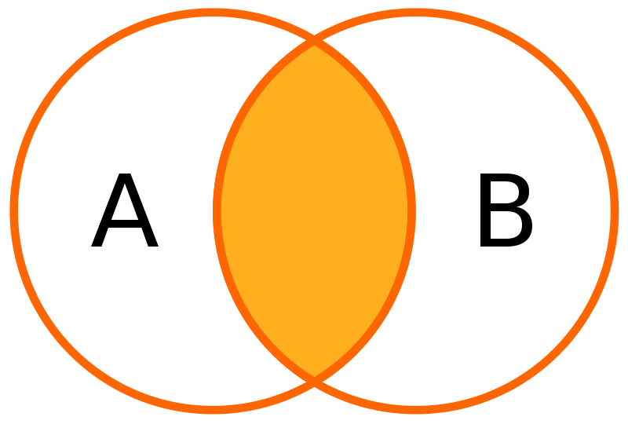

```r
merge(Employees, Departments, all = FALSE, by = "department")
```

```
##    department employee_id  name salary department_name manager
## 1:         11           1 Alice    800      Production       1
## 2:         11           2   Bob    600      Production       1
## 3:         12           3 Carla    900           Sales       4
## 4:         12           4   Dan    100           Sales       4
## 5:         13           5   Eva    800       Marketing       5
```

- Only includes rows which have a `department` in both datasets.
- Fred not included because his department, 21, is not in the departments table.

## Left Outer Join

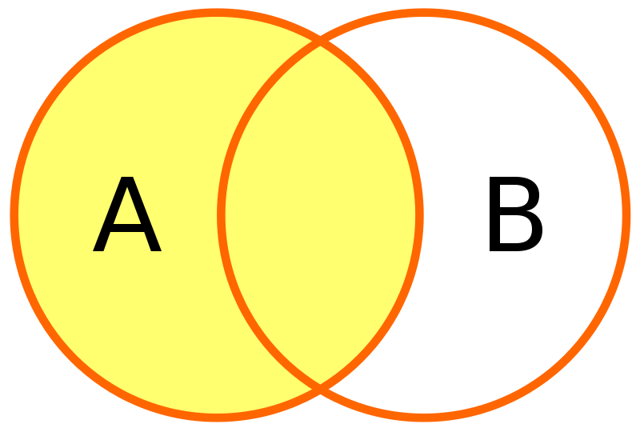

```r
merge(Employees, Departments, all.x = TRUE, by = "department")
```

```
##    department employee_id  name salary department_name manager
## 1:         11           1 Alice    800      Production       1
## 2:         11           2   Bob    600      Production       1
## 3:         12           3 Carla    900           Sales       4
## 4:         12           4   Dan    100           Sales       4
## 5:         13           5   Eva    800       Marketing       5
## 6:         21           6  Fred    700              NA      NA
```

- Only includes rows which have a `department` in the Employees dataset.
- Fred is now included.
- The research department, which has no people, is not included.

## Right Outer Join

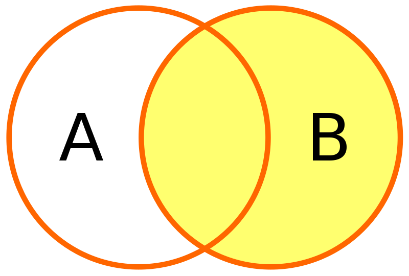

```r
merge(Employees, Departments, all.y = TRUE, by = "department")
```

```
##    department employee_id  name salary department_name manager
## 1:         11           1 Alice    800      Production       1
## 2:         11           2   Bob    600      Production       1
## 3:         12           3 Carla    900           Sales       4
## 4:         12           4   Dan    100           Sales       4
## 5:         13           5   Eva    800       Marketing       5
## 6:         14          NA    NA     NA        Research      NA
```

- Only includes rows which have a `department` in the Departments dataset.
- Fred is now excluded.
- The research department, which has no people, is now included.

## Full Outer Join

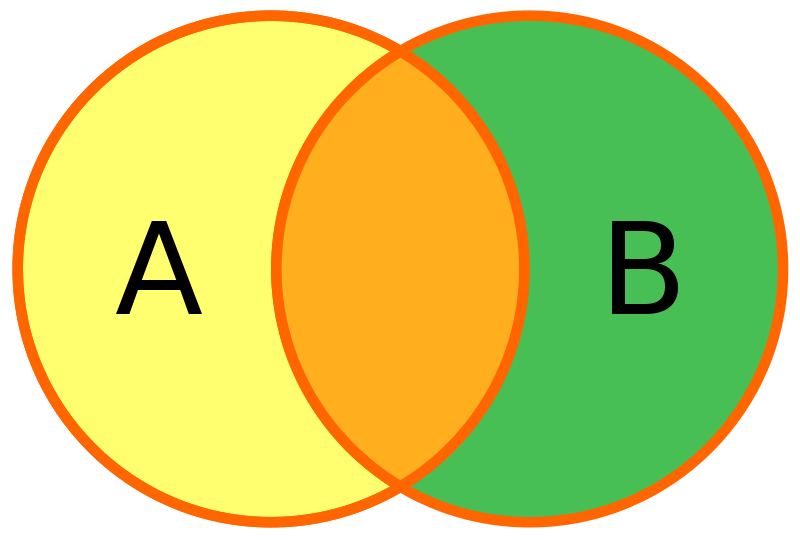

```r
merge(Employees, Departments, all = TRUE, by = "department")
```

```
##    department employee_id  name salary department_name manager
## 1:         11           1 Alice    800      Production       1
## 2:         11           2   Bob    600      Production       1
## 3:         12           3 Carla    900           Sales       4
## 4:         12           4   Dan    100           Sales       4
## 5:         13           5   Eva    800       Marketing       5
## 6:         14          NA    NA     NA        Research      NA
## 7:         21           6  Fred    700              NA      NA
```

- Include all rows.
- Fred and Research both present.

## Tidy Data

- “Happy families are all alike; every unhappy family is unhappy in its own way”
- Tidy datasets are all alike but every messy dataset is messy in its own way.
- Principles:
1. Each variable forms a column.
2. Each observation forms a row.
3. Each type of observational unit forms a table
- More info: http://vita.had.co.nz/papers/tidy-data.pdf

## Example

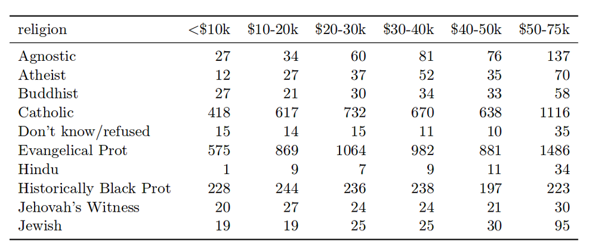

## Example

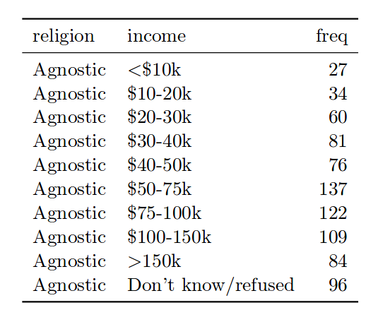

## How to deal with in R

- Want to show the price of different stocks over time.
- Use the `gather` command from the `tidyr` package.

```r
stocks <- data.frame(
  time = as.Date('2009-01-01') + 0:9,
  A = rnorm(10, 0, 1.5),
  B = rnorm(10, 0, 2.5),
  X = rnorm(10, 0, 1),
  Y = rnorm(10, 0, 2),
  Z = rnorm(10, 0, 4)
)
head(stocks)
```

```
##         time           A         B          X          Y          Z
## 1 2009-01-01 -0.31756730 1.9685749 -1.3750772  0.3591336 -9.2476880
## 2 2009-01-02  1.09649868 1.2568864 -1.6930464 -0.8482934  0.5806695
## 3 2009-01-03 -0.09441997 3.9967456  1.9412850  0.1915362  1.5357168
## 4 2009-01-04 -1.68542982 3.2402795  0.3078204  3.6513780  3.4010841
## 5 2009-01-05 -2.13505550 0.5184136  0.8889016  1.6128431  1.6476319
## 6 2009-01-06 -0.79167229 1.9002664 -0.4918359 -0.9816116  2.9226034
```

```r
# exclude time
# every other column will be transformed.
stocks2 <- gather(stocks, key = "stock", value = "price", -time)
head(stocks2)
```

```
##         time stock       price
## 1 2009-01-01     A -0.31756730
## 2 2009-01-02     A  1.09649868
## 3 2009-01-03     A -0.09441997
## 4 2009-01-04     A -1.68542982
## 5 2009-01-05     A -2.13505550
## 6 2009-01-06     A -0.79167229
```

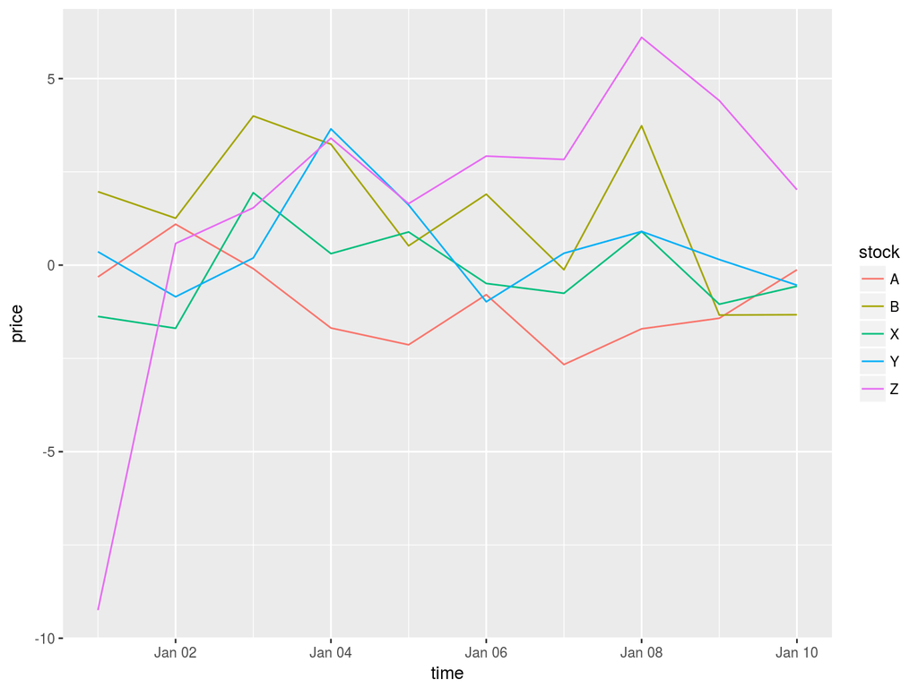

```r
ggplot(stocks2, aes(x = time, y = price, color = stock)) + geom_line()
```

## Cool way to put text in plots

- May find this useful to label plots.
- https://github.com/slowkow/ggrepel

```r
library(ggrepel)
library(cowplot) # for grid
set.seed(42)

#dat <- subset(mtcars, wt > 2.75 & wt < 3.45)
mtcars_dt <- data.table(mtcars)
mtcars_dt[, car := rownames(mtcars)]
# subset cars with 2.75 < wt < 3.45
dat <- mtcars_dt[wt > 2.75 & wt < 4.45,]
head(dat)
```

```
##     mpg cyl  disp  hp drat    wt  qsec vs am gear carb               car
## 1: 21.0   6 160.0 110 3.90 2.875 17.02  0  1    4    4     Mazda RX4 Wag
## 2: 21.4   6 258.0 110 3.08 3.215 19.44  1  0    3    1    Hornet 4 Drive
## 3: 18.7   8 360.0 175 3.15 3.440 17.02  0  0    3    2 Hornet Sportabout
## 4: 18.1   6 225.0 105 2.76 3.460 20.22  1  0    3    1           Valiant
## 5: 14.3   8 360.0 245 3.21 3.570 15.84  0  0    3    4        Duster 360
## 6: 24.4   4 146.7  62 3.69 3.190 20.00  1  0    4    2         Merc 240D
```

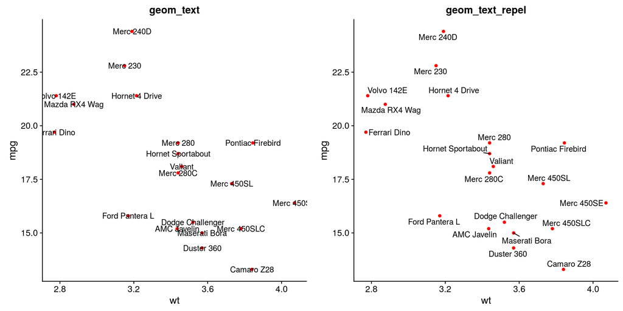

```r
p <- ggplot(dat, aes(wt, mpg, label = car)) + geom_point(color = 'red')

p1 <- p + geom_text() + ggtitle("geom_text")
p2 <- p + geom_text_repel() + ggtitle("geom_text_repel")
plot_grid(p1, p2, nrow = 1)
```